# PA1_template.Rmd

Bishnu Poudel

March 19, 2019

# Week 2 Assignment for Reporducible Research

## Task 1

What is mean total number of steps taken per day? For this part of the assignment, you can ignore the missing values in the dataset.

1. Calculate the total number of steps taken per day

```r
data<-read.csv("activity.csv")
#calculate sum of each day
daysum<- data.frame(  steps_per_day= tapply( data$steps, data$date, sum )
                , date= names(  tapply( data$steps,data$date, sum )  ) )
row.names(daysum)<-NULL
```

2. If you do not understand the difference between a histogram and a barplot, research the difference between them. Make a histogram of the total number of steps taken each day

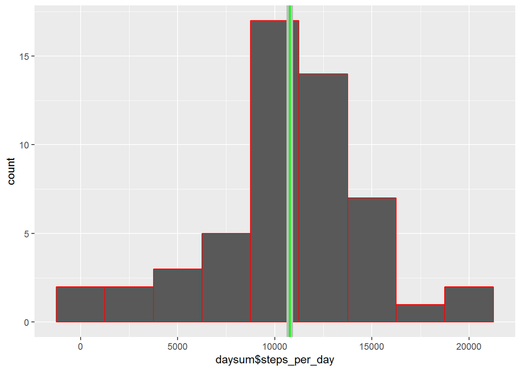

```r
#Histogram
library(ggplot2)
g<- ggplot(daysum, aes(daysum$steps_per_day) )
g+geom_histogram( binwidth=2500, color="red" )+geom_vline(xintercept
=mean(daysum$steps_per_day, na.rm=TRUE),lwd=3, color="gray" ) +geom_vline(xintercept
=median(daysum$steps_per_day, na.rm=TRUE),lwd=1, color="green" )
```

3. Calculate and report the mean and median of the total number of steps taken per day

```r
#display the mean and median which are very close
mean(daysum$steps_per_day, na.rm=TRUE)
```

```
## [1] 10766.19
```

```r
median(daysum$steps_per_day, na.rm=TRUE)
```

```
## [1] 10765
```

## Task 2

What is the average daily activity pattern?

1. Make a time series plot ( type=“l”) of the 5-minute interval (x-axis) and the average number of steps taken, averaged across all days (y-axis)

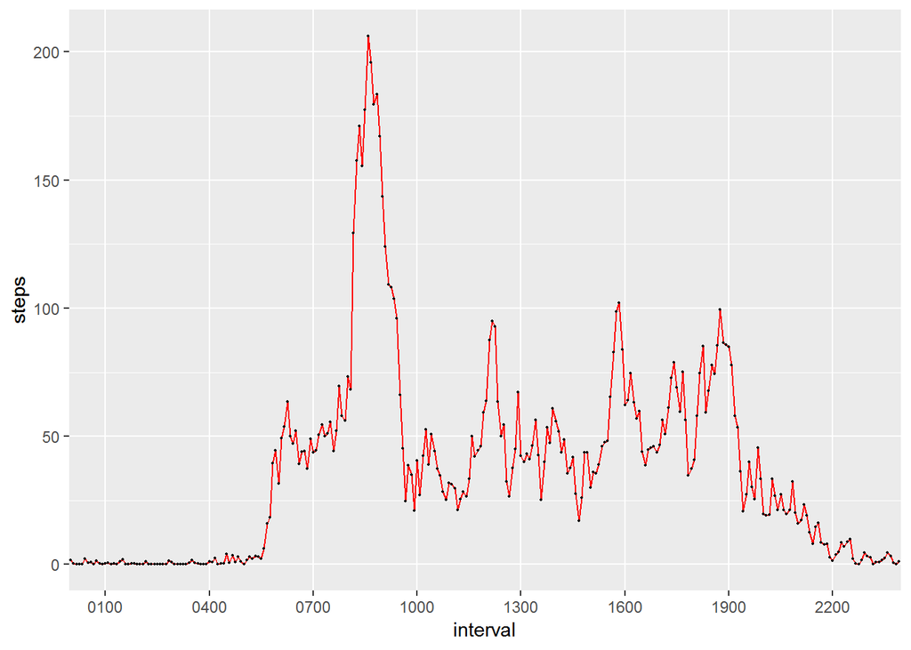

```r
#Plot of each five minute interval. ( 12*24) There should be 288 in the x axis
# could've replaced NA in steps with zeros
# tapply with na.rm=TRUE, this gives different mean
inter1<-tapply( data$steps, data$interval, function(x) mean(x, na.rm=TRUE) )
inter1 <- data.frame( interval= names(inter1), steps=inter1)
row.names(inter1)<-NULL
inter<-inter1
inter1$interval <-as.numeric ( as.character(inter1$interval))
inter$interval<- sprintf( "%04d", as.numeric ( as.character(inter$interval)) )

#plot
g<- ggplot(inter, aes(interval, steps, group=1))
br<-c("0100","0400","0700","1000","1300","1600","1900","2200")
g+geom_line(color="red")+geom_point(lwd=0.3)+xlab("interval")+scale_x_discrete(breaks=br)
```

2. Which 5-minute interval, on average across all the days in the dataset, contains the maximum number of steps?

```r
#Interval where steps are max
inter[inter$steps==max(inter$steps ),]$interval
```

```
## [1] "0835"
```